# Welcome to Financial Economics

ECON 4810 WSU Fall 2025 25216

Valentinas Rudys, Fall 2025

Financial Economics (ECON 4810 WSU Fall 2025 25216) counts as:

- Upper Division Finance Elective (Major Elective)
- Upper Division Economics Elective (Major Elective)
- Upper Division / General / Additional Elective

Prerequisites for this course:

- Either ECON 2010 (Principles of Microeconomics)
- Or ECON 2020 (Principles of Macroeconomics)

This experimental financial economics course explores the principles of financial decision-making and asset pricing using economic theory great for students interested in how financial markets work, household decisions are made, and how assets are priced. We will cover saving, interest rates, investments, insurance, and even gambling and do this through your lens. In this course, we will start each topic with the real questions we all care about, then developing the theories, discussing the results and comparing them with the real data. We will ask questions like:

- Buy or lease a car? Sell it, trade it in, or rent it out on Turo? If you move, should you sell your house or rent it out? Rent short-term or long-term? And how low must interest rates go before refinancing is worth it?
- How much should you borrow or save now—and a few years after graduation? Should you pay off your student loans early or invest instead? Do you need life insurance at 25?
- How should your money be split between stocks, bonds, gold, and Bitcoin? Should your strategy change after a promotion—or a breakup?
- Is skipping health insurance ever smart? Should you insure your iPhone or your pet? How do you best hedge your risks - with futures or options? When—if ever—does buying a Powerball ticket make economic sense?

To answer these and many other relevant questions, we will build financial models from scratch using Python, and compare the predictions to the messy real-world data. We will take full advantage of AI tools in improving our models and will have opportunities to develop your interests into full-fledged research papers.

This course is great for:

- Economics, Finance and Business students interested in
  - Economic theory and models behind the saving and investment decision
  - Improving programming skills and learning to compare model predictions with data
  - Better understanding saving, investment decisions over the lifecycle
  - Investment decisions in cars, homes, bonds, stocks, crypto, gold
  - Value and pricing of insurance and gambling
- Finance students specifically interested in:
  - Working toward CFP credentials because we will cover many topics tested in CFP examination:
    - Risk management, evaluation of risk and insurance (section C of CFP exam)
    - Investment planning, portfolio allocation over the lifecycle (section D)
    - Alternative investments (section D)
    - Retirement and social security and planning (section F)

### Example Discussion 1: Consumption, saving and investing over the lifecycle

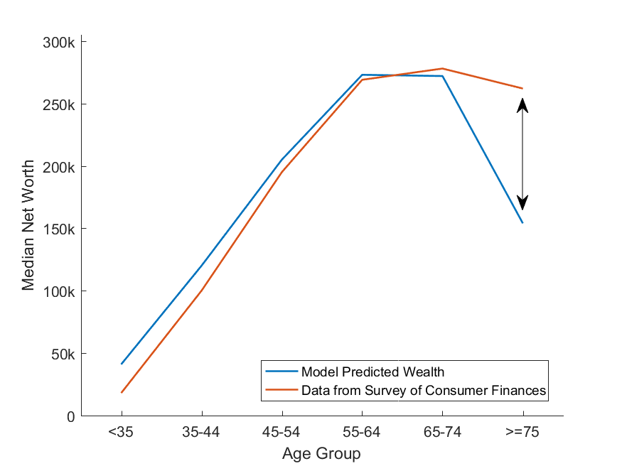

The lifecycle hypothesis states that households will save and invest early in their lives and dissave later when incomes are lower. Such saving and then dissaving behavior allows people to smooth consumption over the lives avoiding periods of feasts and famines. By developing a simple saving model and comparing it with the data, we will find that the model overstates the dissaving in the later stages of life. We will enhance the model to bridge the gap between model predictions and data, discuss implications and develop and test new hypotheses.

### Example Discussion 2: Investing in stocks over the lifecycle

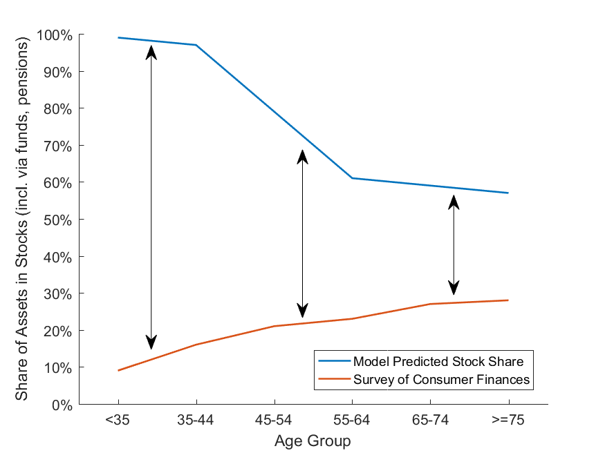

We will build a model predicting optimal investment in stock and bonds. We will find that under standard assumptions, the lifecycle investment models predict significantly higher mean optimal allocation to stocks. The data suggests that both stock ownership (fraction of people that own any stocks) and stock share of financial assets is significantly lower than predicted. The gap between observed and predicted stock ownership is even bigger (50% compared to 100%). We will modify the model and analyze the main features the investment models omit. We will update the models and discuss insights from our analyses about age, risk, returns and household behavior over the lifecycle. We will expand the discussion to gold, cryptocurrencies, and other asset groups.

### Example Discussion 3: Hedging oil price volatility

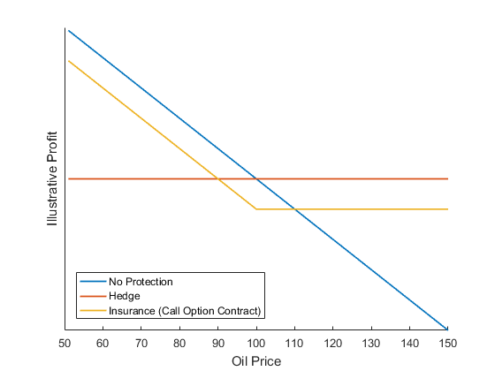

Many firms face significant cost fluctuations due to the volatility of oil prices. For low-cost airlines such as Southwest in the U.S. and Ryanair or Wizz Air in Europe, fuel expenses can account for as much as 40% of total operating costs. To manage the risk of rising fuel prices, these companies often hedge or insure against future increases by using financial instruments such as futures, forwards, options, and swaps. In this section, we explore the optimal level of protection: What distinguishes insurance from hedging? How should a firm decide how much protection to secure—and how much it is worth paying for it?

### Example Discussion 4: Is it rational to buy insurance and gamble

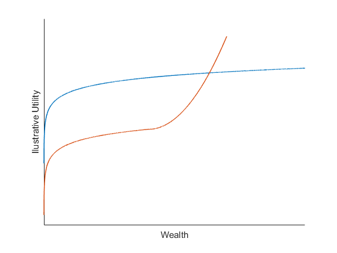

Many people insure their homes and health to protect against adverse outcomes, demonstrating clear risk-averse behavior. Yet, paradoxically, many of these same individuals also purchase lottery tickets, gamble in casinos, bet on sports, or invest in highly speculative assets like cryptocurrencies and meme stocks. At first glance, this seems contradictory—how can the same person be both risk-averse and risk-seeking? In this section, we’ll explore economic frameworks that resolve this puzzle by showing that individuals may exhibit different attitudes toward risk depending on their level of wealth or the context of the decision. It can be entirely rational to insure against large, potentially ruinous losses while simultaneously embracing small-stakes gambles that offer the possibility of a high payoff.